# Лабораторная работа №16

Основы администрирования операционных систем

Верниковская Е. А., НПИбд-01-23

Российский университет дружбы народов, Москва, Россия

21 декабря 2024

# Вводная часть

## Цель работы

Освоить работу с RAID-массивами при помощи утилиты mdadm.

## Задание

1. Добавить три диска на виртуальную машину (объёмом от 512 MiB каждый). При помощи sfdisk создать на каждом из дисков по одной партиции, задав тип раздела для RAID
2. Создать массив RAID 1 из двух дисков, смонтировать его. Эмитировать сбой одного из дисков массива, удалить искусственно выведенный из строя диск, добавить в массив работающий диск
3. Создать массив RAID 1 из двух дисков, смонтировать его. Добавить к массиву третий диск. Эмитировать сбой одного из дисков массива. Проанализировать состояние массива, указать различия по сравнению с предыдущим случаем
4. Создать массив RAID 1 из двух дисков, смонтировать его. Добавить к массиву третий диск. Изменить тип массива с RAID1 на RAID5, изменить число дисков в массиве с 2 на 3. Проанализировать состояние массива, указать различия по сравнению с предыдущим случаем

# Выполнение лабораторной работы

## Создание виртуальных носителей

Добавляем к нашей виртуальной машине к контроллеру SATA три диска размером 512 MiB (рис. 1)

[figure not shown]

Добавление к контроллеру SATA трёх дисков

## Создание виртуальных носителей

Запускаем терминала и получаем полномочия суперпользователя, используя *su -* (рис. 2)

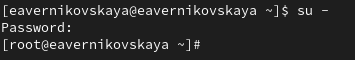

Режим суперпользователя

## Создание виртуальных носителей

Проверим наличие созданных нами на предыдущем этапе дисков: *fdisk -l | grep /dev/sd*. В системе добавленные диски отображаются как /dev/sdd, /dev/sde, /dev/sdf (рис. 3)

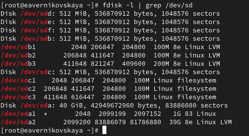

Проверка наличия созданных дисков

## Создание виртуальных носителей

Создадим на каждом из дисков раздел: *sfdisk /dev/sdd <<EOF*, *sfdisk /dev/sde <<EOF* и *sfdisk /dev/sdf <<EOF* (рис. 4), (рис. 5), (рис. 6)

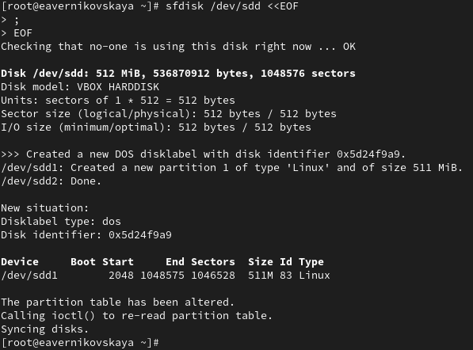

Создание раздела на диске /dev/sdd

## Создание виртуальных носителей

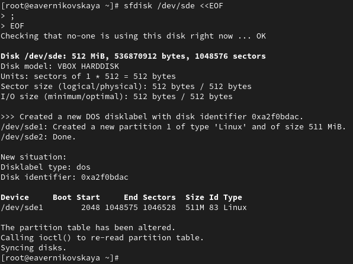

Создание раздела на диске /dev/sde

## Создание виртуальных носителей

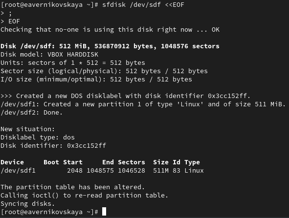

Создание раздела на диске /dev/sdf

## Создание виртуальных носителей

Проверим текущий тип созданных разделов: *sfdisk –print-id /dev/sdd 1*, *sfdisk –print-id /dev/sde 1* и *sfdisk –print-id /dev/sdf 1*. Созданные нами разделы на дисках имеют тип 83 (Linux) (рис. 7)

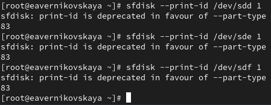

Проверка текущего типа созданных разделов

## Создание виртуальных носителей

Посмотрим, какие типы партиций, относящиеся к RAID, можно задать: *sfdisk -T | grep -i raid* (рис. 8)

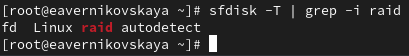

Типы партиций, относящиеся к RAID

## Создание виртуальных носителей

Установим тип разделов в Linux raid autodetect: *sfdisk –change-id /dev/sdd 1 fd*, *sfdisk –change-id /dev/sde 1 fd* и *sfdisk –change-id /dev/sdf 1 fd* (рис. 9)

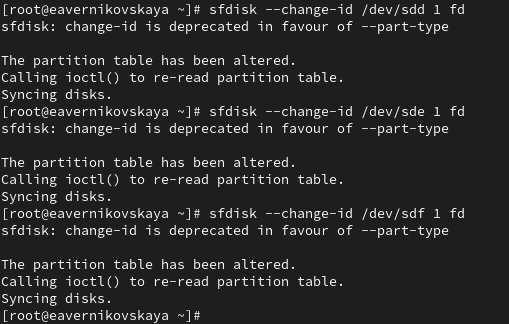

Установление типа разделов в Linux raid autodetect

## Создание виртуальных носителей

Посмотрим состояние дисков: *sfdisk -l /dev/sdd*, *sfdisk -l /dev/sde* и *sfdisk -l /dev/sdf*. Тип разделов изменился на Linux raid autodetect (рис. 10)

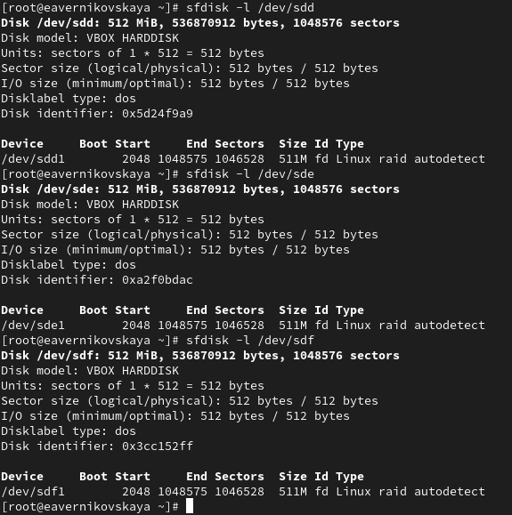

Состояния дисков

## Создание виртуальных носителей

При помощи утилиты *mdadm* создадим массив RAID 1 из двух дисков: *mdadm –create –verbose /dev/md0 –level=1 –raid-devices=2 /dev/sdd1 /dev/sde1* (рис. 11)

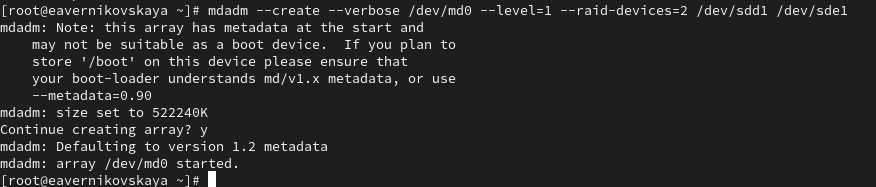

Создание массива RAID 1 из двух дисков (1)

## Создание виртуальных носителей

Проверим состояние массива RAID, используя команды *cat /proc/mdstat*, *mdadm –query /dev/md0* и *mdadm –detail /dev/md0* (рис. 12)

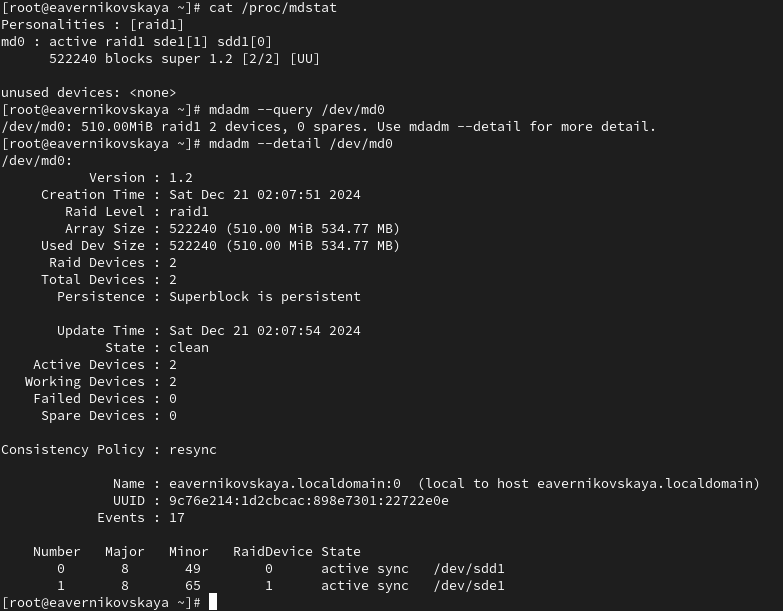

Состояние массива RAID (1)

## Создание виртуальных носителей

Создадим файловую систему на RAID: *mkfs.ext4 /dev/md0* (рис. 13)

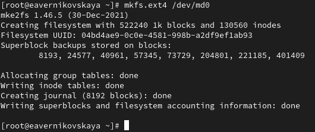

Создание файловой системы ext4 на RAID

## Создание виртуальных носителей

Подмонтируем RAID: *mkdir /data* и *mount /dev/md0 /data* (рис. 14)

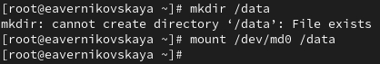

Подмонтирование RAID

## Создание виртуальных носителей

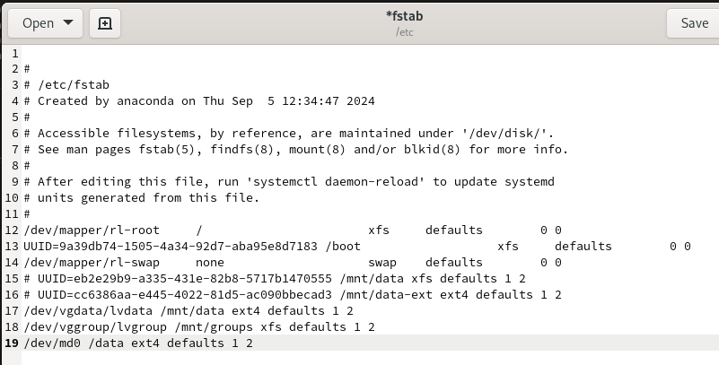

Редактирование файла /etc/fstab (1)

## Создание виртуальных носителей

Сымитируем сбой одного из дисков: *mdadm /dev/md0 –fail /dev/sde1* (рис. 17)

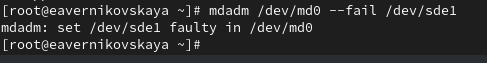

Имитирование сбоя диска /dev/sde1 (1)

## Создание виртуальных носителей

Удалим сбойный диск: *mdadm /dev/md0 –remove /dev/sde1* (рис. 18)

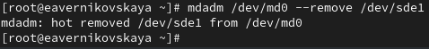

Удаление сбойного диска /dev/sde1

## Создание виртуальных носителей

Заменим диск в массиве: *mdadm /dev/md0 –add /dev/sdf1* (рис. 19)

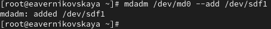

Замена сбойного диска на /dev/sdf1

## Создание виртуальных носителей

Посмотрим состояние массива (рис. 20)

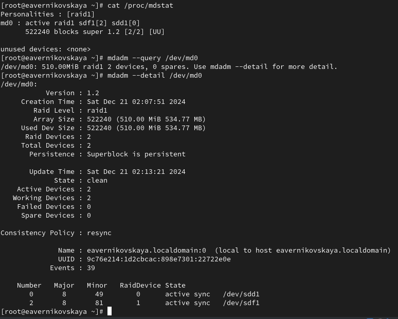

Состояние массива RAID (2)

## Создание виртуальных носителей

Удалим массив и очистим метаданные: *umount /dev/md0*, *mdadm –stop /dev/md0*, *mdadm –zero-superblock /dev/sdd1*, *mdadm –zero-superblock /dev/sde1* и *mdadm –zero-superblock /dev/sdf1* (рис. 21)

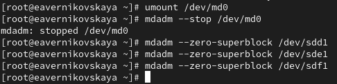

Удаление массива и очистка метаданных (1)

## RAID-массив с горячим резервом (hotspare)

Создадим массив RAID 1 из двух дисков: *mdadm –create –verbose /dev/md0 –level=1 –raid-devices=2 /dev/sdd1 /dev/sde1* (рис. 22)

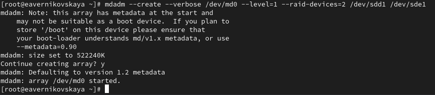

Создание массива RAID 1 из двух дисков (2)

## RAID-массив с горячим резервом (hotspare)

Добавим третий диск: *mdadm –add /dev/md0 /dev/sdf1* (рис. 23)

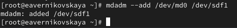

Добавление третьего диска /dev/sdf1 (1)

## RAID-массив с горячим резервом (hotspare)

Подмонтируем /dev/md0 *mount /dev/md0* (рис. 24)

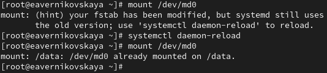

Подмонтирование /dev/md0 (1)

## RAID-массив с горячим резервом (hotspare)

Проверим состояние массива (рис. 25)

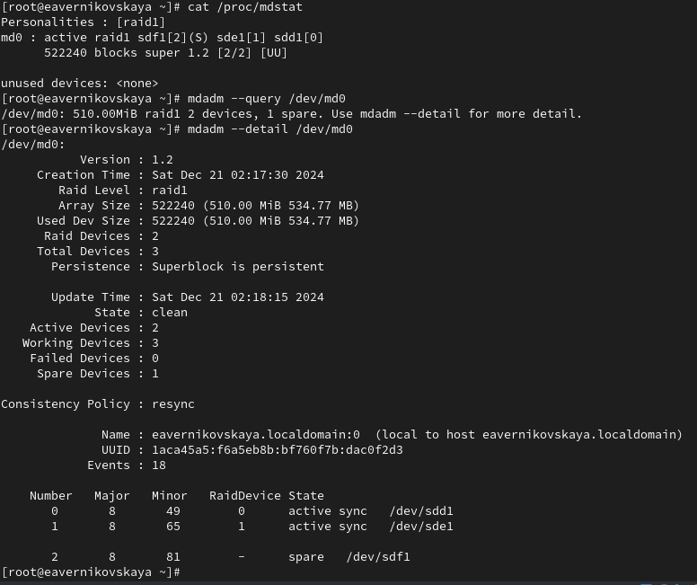

Состояние массива RAID (3)

## RAID-массив с горячим резервом (hotspare)

Сымитируем сбой одного из дисков: *mdadm /dev/md0 –fail /dev/sde1* (рис. 26)

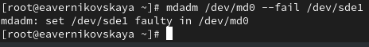

Имитирование сбоя диска /dev/sde1 (2)

## RAID-массив с горячим резервом (hotspare)

Проверим состояние массива: *mdadm –detail /dev/md0* (рис. 27)

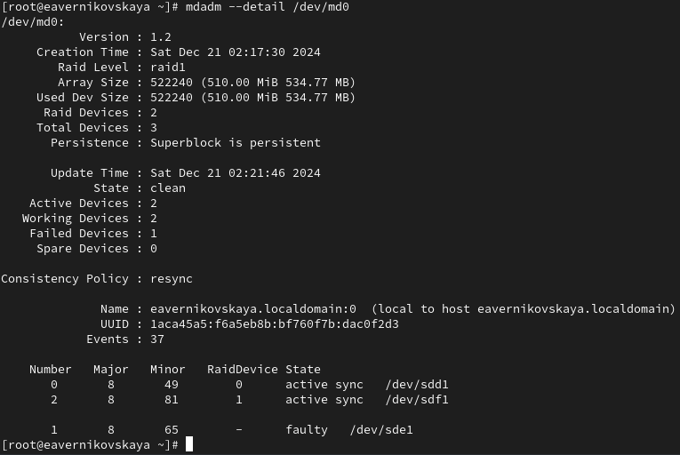

Состояние массива RAID (4)

## RAID-массив с горячим резервом (hotspare)

Удалим массив и очистим метаданные (рис. 28)

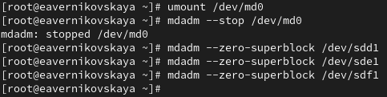

Удаление массива и очистка метаданных (2)

## Преобразование массива RAID 1 в RAID 5

Создайте массив RAID 1 из двух дисков: *mdadm –create –verbose /dev/md0 –level=1 –raid-devices=2 /dev/sdd1 /dev/sde1* (рис. 29)

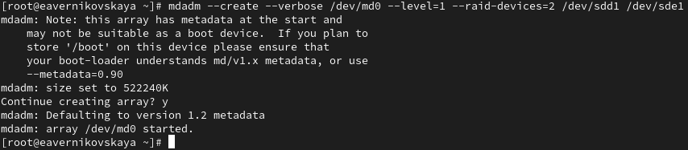

Создание массива RAID 1 из двух дисков (3)

## Преобразование массива RAID 1 в RAID 5

Добавим третий диск: *mdadm –add /dev/md0 /dev/sdf1* (рис. 30)

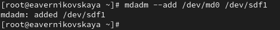

Добавление третьего диска /dev/sdf1 (2)

## Преобразование массива RAID 1 в RAID 5

Проверим состояние массива (рис. 32)

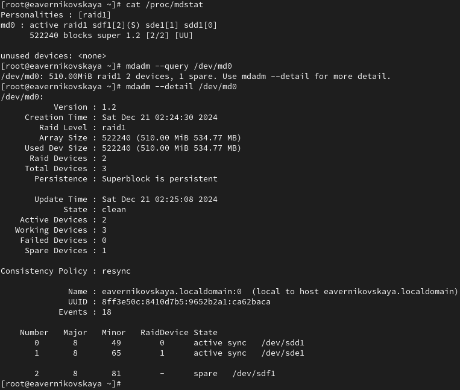

Состояние массива RAID (5)

## Преобразование массива RAID 1 в RAID 5

Измените тип массива RAID: *mdadm –grow /dev/md0 –level=5* (рис. 33)

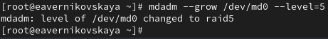

Изменение типа массива RAID